# AB-Cloud Monograph v22.1 (RU)

Нули дзета-функции Римана, GUE-универсальность и топологическое вихревое вещество: полное численное исследование с независимой верификацией

Исаев Исхак Хамзатович (ORCID: 0009-0003-7299-0701)

Версия 22 · Август 2026

# Аннотация

Настоящая монография написана заново, «с чистого листа», и подводит итог систематического численного исследования объекта, который мы называем **AB-облаком**: решёточной квантовой системы (гамильтониан Хофштадтера с фазами Ааронова–Бома), в которой топологические вихревые возбуждения создают неоднородное фазовое поле, а распределение собственных значений сравнивается со статистикой нулей дзета-функции Римана. Всё, что здесь утверждается, снабжено воспроизводимыми числами из автоматизированной верификационной сюиты из 37 тестов (версии 18/19, август 2026 г.); каждая цифра снабжена номером теста, каждый тест — полным журналом вычислений, а каждый запуск сюиты оставляет на диске каталог с отчётами в четырёх форматах (Markdown, HTML, PDF, DOCX), графиками в трёх векторных и растровых форматах и покадровыми логами.

Совокупность результатов образует связный нарратив: AB-облако — это фазовый резонатор, в котором универсальная GUE-статистика возникает из-за нарушения симметрии обращения времени комплексными фазами прыжков, вихри ведут себя как релятивистские частицы, а критическая прямая *σ* = 1/2 выделяется как точка самодуальности, в которой статистика облака ближе всего к статистике нулей дзета-функции. Мы отделяем доказанное (машинная точность), надёжно измеренное (статистические полосы) и остающееся открытым (асимптотика больших *T*), снабжая каждый вывод явным критерием — читателю не придётся верить на слово ни одному числу в этой книге.

**Ключевые слова:** гипотеза Гильберта–Поля; дзета-функция Римана; теория случайных матриц; GUE; эффект Ааронова–Бома; гамильтониан Хофштадтера; AB-облако; топологические вихри; дираковский конус; TKNN; скин-эффект Хатано–Нельсона.

# 1. Введение и постановка задачи

## 1.1 Гипотеза Гильберта–Поля

В 1914 году Риман высказал гипотезу, что все нетривиальные нули дзета-функции *ζ*(*s*) лежат на критической прямой Re *s* = 1/2. Спустя почти полвека, в 1958 году, Дэвид Гильберт (по воспоминаниям Пойи) предложил стратегию доказательства, которая с тех пор называется **гипотезой Гильберта–Поля**: если найти самосопряжённый оператор *Ĥ*, спектр которого совпадает с ординатами нулей {*γ*<sub>*n*</sub>}, то гипотеза Римана стала бы теоремой — эрмитовость оператора немедленно влечёт вещественность всех собственных значений, то есть Re *γ*<sub>*n*</sub> = 1/2 для всех *n*. Красота этой программы в том, что она переводит аналитическую теорию чисел на язык квантовой механики: нули дзета-функции становятся энергетическими уровнями некоторой (пока неизвестной) физической системы.

Гипотеза остаётся недоказанной, но именно она задаёт рамку настоящей работы: мы строим и исследуем конкретный класс квантовых решёточных систем, спектральная статистика которых демонстрирует количественное сближение со статистикой нулей. Важно подчеркнуть методологическую позицию, отличающую эту монографию от многих предшествующих текстов на данную тему: мы **не утверждаем доказательства гипотезы Римана**. Наш объект — точная численная характеристика того, насколько близко конечные решёточные ансамбли подходят к универсальной случайноматричной статистике, и какие параметры приближают или отдаляют это сближение. Все критерии «близости» определены заранее, до запуска тестов, и не подстраиваются по ходу исследования.

Исторический контекст коротко таков. В 1972 году Монтгомери сформулировал гипотезу о парной корреляции нулей *ζ*; Дисон, случайно встретившись с Монтгомери в чаепательной комнате Принстонского института перспективных исследований, указал, что формула Монтгомери совпадает с парной корреляцией собственных значений ансамбля GUE (гауссов унитарный ансамбль) теории случайных матриц. В 1980-е годы Одлыжко на огромном вычислительном материале подтвердил это совпадение численно, а Берри в 1985 году вычислил конечномерные поправки: реальная (ограниченная по *T*) выборка нулей должна отклоняться от чистого GUE предсказуемым образом — в частности, значение парной корреляции в нуле *R*<sub>2</sub>(0) получает поправку, экспоненциально или степенно малую по *T*. Эти поправки критически важны для нас: именно они объясняют, почему наши тесты 4–6 и 11 видят статистически значимые отклонения от GUE на выборках *T* ≲ 4 ⋅ 10<sup>4</sup>, и почему это отклонение не опровергает, а подтверждает картину.

## 1.2 Эффект Ааронова–Бома и AB-облако

**AB-облаком** мы называем обобщение этой модели, в котором на решётку помещены точечные **топологические вихри** — центры, вокруг которых фаза прыжков закручена на 2*π**q* (*q* — заряд вихря, может быть дробным). Фазовое поле такой системы неоднородно: вблизи каждого вихря фаза «клубится», и суммарная картина напоминает облако — отсюда название. Математически гамильтониан записывается как

$$H_{ij} =
-\exp\bigl(i\varphi_{ij}\bigr),\qquad \varphi_{ij} = 2\pi\alpha\,j +
\sum_{k=1}^{N_v} q_k\bigl[\arg(\mathbf r_i - \mathbf r_k) - \arg(\mathbf
r_j - \mathbf r_k)\bigr] + \varphi^{\rm str}_{ij},$$

где *j* — номер столбца решётки (калибровка Ландау), *N*<sub>*v*</sub> — число вихрей, а $\varphi^{\rm str}_{ij}$ — явная **дираковская нить**: добавка −2*π**q*, приписываемая тем связям, которые пересекают полупрямую (нить), выходящую из вихря. Дираковская нить гарантирует, что суммарный магнитный поток вокруг вихря равен ровно 2*π**q* с точностью до машинного эпсилона — это проверено прямыми вычислениями (тесты 15, 24).

Кроме геометрической (фазовой) части, модель содержит **диагональный беспорядок** *W*: аддитивный шум на узлах, моделирующий примеси реального кристалла. Параметры модели — размер решётки *L* × *L*, поток *α*, набор зарядов {*q*<sub>*k*</sub>}, число и позиции вихрей *N*<sub>*v*</sub>, сила беспорядка *W* и тип граничных условий (открытые или тор). Ключевой физический переключатель — **модель фаз вихрей**: (а) калибровка дираковской нити, в которой целозарядные вихри спектрально невидимы (это точная теорема Байерса–Янга, тест 25), и (б) гладкая калибровка `:monumental` (atan-модель), в которой фазы распределены плавно и комплексны уже при любом *q* — именно она делает GUE-статистику достижимой при физически разумных параметрах. Обе калибровки реализованы в коде и применяются по назначению: потоковые теоремы проверяются в первой, статистика спектра — во второй.

## 1.3 Связь с теорией случайных матриц

**Теория случайных матриц (ТСМ)** изучает распределения собственных значений больших матриц со случайными элементами. Для нас существенны три ансамбля, различающиеся симметрией обращения времени: **GOE** (вещественные симметричные матрицы, T-симметрия сохранена), **GUE** (комплексные эрмитовы, T-симметрия нарушена) и **GSE** (кватернионные самодвойственные), а также предельный **пуассоновский** случай (некоррелированные уровни, интегрируемая система). Диагностические величины, которые мы используем, определены в разделе 2.2; здесь отметим только основную шкалу среднего отношения соседних зазоров: ⟨*r*⟩ ≈ 0, 386 (Пуассон), $0, 531$ (GOE), $0, 600$ (GUE). Тройная классификация Дайсона предсказывает, что нарушение T-симметрии комплексными фазами обязано переводить систему в класс GUE — это «тройной путь Дайсона», и AB-облако в гладкой калибровке является его пряной иллюстрацией: при *α* = 1/2 матрица комплексно-эрмитова, *τ*(*H*) = ∥*H* − *H**∥/∥*H*∥ = 0, 225 ≠ 0 (тест 26), и статистика действительно тяготеет к GUE, тогда как в вещественной калибровке дираковских нитей *τ* = 0 и спектр заперт в классе GOE (тесты 15, 16).

## 1.4 Цели, задачи и организация верификации

Цель работы — построить полную, независимо проверяемую картину спектральной физики AB-облака. Задачи конкретизированы в виде 37 автоматизированных тестов, сгруппированных в шесть блоков: (1) сходимость поправки *b*(*N*) и возражения критиков (тесты 1–14); (2) построение и топологические теоремы (15, 17, 20, 24–27); (3) GUE-классификация облака (16, 26, 29, 33, 34); (4) прямое сравнение с нулями *ζ* (28, 35, 36); (5) дираковская динамика и неэрмитовость (19, 30–32, 37); (6) аналитические интерпретации (тесты 21–23 и раздел 8). Каждый тест возвращает булев вердикт по заранее зафиксированному критерию; верификация двухпроходная (первый проход — основная решётка, второй — увеличенная), а «быстрая проверка» прогоняет все 37 тестов на решётках $16 × 16 → 32 × 32$ с усечённой до 5000 нулей ζ-выборкой за считанные минуты.

Отдельно оговорим **две системы вердиктов**, чтобы читатель не путал их. Формульные тесты (тождества: потоки, самодуальность, Байерс–Янг) проверяются с машинными допусками 10<sup>−12</sup>…10<sup>−16</sup> и дают бинарный вердикт PASS/FAIL. Статистические тесты (GUE-согласие) калиброваны по доверительным полосам, установленным из моделирования: например, PASS по ⟨*r*⟩ требует попадания в полосу $0, 5992 ± 0, 022$; для них возможен третий вердикт WARN — «отклонение измерено, но объясняется конечномерностью». Такая двойная система исключает главный грех численных работ — подгонку критериев под результат.

# 2. Математический аппарат

## 2.1 Дзета-функция Римана и нули

**Дзета-функция Римана** *ζ*(*s*) = ∑<sub>*n* ≥ 1</sub>*n*<sup>−*s*</sup> аналитически продолжается на всю комплексную плоскость и имеет нетривиальные нули в критической полосе 0 < Re *s* < 1. В численной работе мы используем первые 50 000 нулей (набор Одлыжко), ординаты которых заполняют интервал *T* ∈ [14, 13; 40433, 7]. Плотность нулей на высоте *T* задаётся **формулой Римана–фон Мангольдта**:

$$N(T) = \frac{T}{2\pi}\ln\frac{T}{2\pi} -
\frac{T}{2\pi} + \frac{7}{8} + O(\ln T),$$

и растёт примерно как (*T*/2*π*)ln *T* — нули «разрежаются» в абсолютном расстоянии, но после деления на локальную плотность становятся однородными. Эта процедура деления называется **развёрткой (unfolding)**: нормированные спейсины *δ*<sub>*n*</sub> = *γ*<sub>*n* + 1</sub><sup>(*u*)</sup> − *γ*<sub>*n*</sub><sup>(*u*)</sup> имеют среднее 1 по построению, и вся информация о корреляциях переносится в их распределение. В коде развёртка реализована симметричным скользящим окном по гладкой функции *N*(*T*); это стандартная процедура, но именно на этом этапе чаще всего возникают артефакты, поэтому тест 10 проверяет устойчивость всех итоговых величин к смене подвыборок (максимальное относительное отклонение 8,5% при пороге 10% — PASS).

Для сравнения ансамблей мы используем статистику нулей на трёх высотах: полная выборка 50 000 нулей (тесты 4, 6–10), «высокотемпературные» подвыборки с *T* > *T*<sub>min</sub> (тест 5) и первые 1000/5000 нулей для двухпроходного сравнения (тесты 28, 35). Асимптотическая природа GUE-статистики означает, что согласие улучшается с ростом *T*; наши данные это прямо демонстрируют (раздел 3.2).

## 2.2 Ансамбли случайных матриц и диагностические статистики

Все диагностические величины определены для развёрнутых (безразмерных) уровней. Мы используем пять величин, каждая из которых чувствительна к своему аспекту корреляций.

**Отношение соседних зазоров** ⟨*r*⟩. Для каждой тройки соседних уровней *E*<sub>*n* − 1</sub>, *E*<sub>*n*</sub>, *E*<sub>*n* + 1</sub> положим *r*<sub>*n*</sub> = min (*δ*<sub>*n*</sub>, *δ*<sub>*n* + 1</sub>)/max (*δ*<sub>*n*</sub>, *δ*<sub>*n* + 1</sub>); усреднение даёт величину, не требующую внешней развёртки (отношения нечувствительны к локальной плотности). Опорные значения (большие матрицы): Пуассон $0, 3863$, GOE $0, 5307$, GUE $0, 5996$. Это главная диагностическая величина для конечных решёточных ансамблей, поскольку не накапливает ошибку развёртки.

**Критерий Колмогорова–Смирнова (KS)**. Сравнивает эмпирическую функцию распределения спейсингов с Wigner-предсказанием GUE: статистика *D* = максимум модуля разности кривых, и при *n* спейсингах критическое значение на уровне 5% равно $1{,}36/\sqrt{n}$. Для *n* = 49999 критическое *D* = 0, 0061 — то есть даже микроскопические отклонения «отвергают» GUE; поэтому мы всегда приводим *D* вместе с *n* и с критическим порогом (тест 4) и отдельно смотрим тренд *D*(*T*<sub>min</sub>) (тест 5).

**Числовая дисперсия *Σ*<sup>2</sup>(*L*)** — дисперсия числа уровней в окне длины *L* (в единицах средней плотности). Пуассон даёт *Σ*<sup>2</sup> = *L*; GUE даёт *Σ*<sup>2</sup> ≈ (1/*π*<sup>2</sup>)ln (2*π**L*) + … — логарифмический, а не линейный рост. Спектральная жёсткость *Δ*<sub>3</sub>(*L*) — интегральная версия того же: среднеквадратичное отклонение наилучшей прямой, аппроксимирующей «лестницу уровней» в окне *L*; Пуассон *L*/15, GUE ≈ (1/*π*<sup>2</sup>)ln *L*. Обе величины вычисляются на общей сетке из 9 значений *L* для данных и для смоделированного GUE-справочника (тесты 13, 14).

**Парная корреляция *R*<sub>2</sub>(*s*)** — плотность вероятности найти уровень на расстоянии *s* от данного (развитие гипотезы Монтгомери): для GUE *R*<sub>2</sub>(*s*) = 1 − (sin *π**s*/(*π**s*))<sup>2</sup>, «корреляционная дыра» в нуле *R*<sub>2</sub>(0) = 0 отражает выталкивание уровней; для Пуассона *R*<sub>2</sub> ≡ 1. Формфактор *K*(*t*) — фурье-образ *R*<sub>2</sub>, «рампа + плато» *K*(*t*) = min (*t*, 1) для GUE; это самая интегральная из наших диагностик (тесты 35, 36).

**Критерий Андерсона–Дарлинга *A*<sup>2</sup>** — аналог KS, взвешенный по хвостам распределения; p-значение мы оцениваем монте-карловски по 2000 симуляций (тест 11). Наконец, **f_GUE** — сводная мера «доли GUE» в данных: $f_{\rm GUE} = (\Sigma^2_{\rm P} - \Sigma^2_{\rm data})/(\Sigma^2_{\rm P} - \Sigma^2_{\rm GUE})$ по значению при *L* = 2; $f_{\rm GUE}=1$ — идеальный GUE, $0$ — Пуассон (тест 29).

## 2.3 Гамильтониан Хофштадтера с вихрями: точное определение

Соберём определение модели полностью. Решётка *L*<sub>*x*</sub> × *L*<sub>*y*</sub>; волновая функция живёт на узлах; матричные элементы *H*<sub>*i**j*</sub> = −exp (*i**φ*<sub>*i**j*</sub>) для ближайших соседей (включая периодические обходы, если выбран тор). Калибровка Ландау приписывает столбцу *j* фазу 2*π**α**j*. Вихрь с зарядом *q*<sub>*k*</sub> в позиции **r**<sub>*k*</sub> = (*x*<sub>*k*</sub>, *y*<sub>*k*</sub>) (координаты в ячейках) добавляет к разности фаз связи (*i* → *j*) величину *q*<sub>*k*</sub>[arg (**r**<sub>*i*</sub> − **r**<sub>*k*</sub>) − arg (**r**<sub>*j*</sub> − **r**<sub>*k*</sub>)], а дираковская нить — дискретную добавку −2*π**q*<sub>*k*</sub> на связях, пересекающих нить; в гладкой калибровке нить отсутствует, но atan-фаза распределяется по вертикальным связям. Ключевое свойство: **сумма фаз вокруг любой ячейки равна 2*π**α* + 2*π**q*<sub>*k*</sub> *δ*<sub>*k*</sub>** (плюс 2*π*⋅целое), где *δ*<sub>*k*</sub> — индикатор того, что ячейка содержит вихрь. Это проверено для всех 224 внутренних ячеек решётки $16 × 16$: максимум |поток| на пустых ячейках 1, 5 ⋅ 10<sup>−14</sup> рад (тест 24).

Диагональный беспорядок *W* реализуется как наузный потенциал *ε*<sub>*i*</sub> ∈ [−*W*/2; *W*/2] с фиксированным зерном генератора (воспроизводимость: одинаковое зерно — одинаковый беспорядок). Существенно, что для топологических тождеств (Байерс–Янг) беспорядок включается на нуле: любая зависимость спектра от *q* кроме чистой калибровки была бы ошибкой, и тест 25 подтверждает это с точностью 3, 5 ⋅ 10<sup>−15</sup>.

Граничные условия — отдельный физический выбор. Открытые границы порождают краевые состояния бабочки Хофштадтера, которые подмешивают пуассоновскую компоненту в спектр и занижают ⟨*r*⟩ (тест 33: на открытых границах $0, 442$ против $0, 585$ на торе при одинаковых прочих параметрах). Тор требует калибровочной совместности *q* (2 − *N*<sub>*x*</sub>) ∈ ℤ — условие периодичности фазы при обходе; для целых *q* оно выполняется автоматически, для дробных *q* = 0, 3 на торе $16 × 16$ оно нарушается, и система честно откатывается на открытые границы (в коде это автоопределение с диагностическим сообщением).

## 2.4 Методология верификации и воспроизводимость

Каждый запуск сюиты создаёт каталог `results/run_<дата-время>/` с подкаталогом на каждый тест: внутри — полный журнал вычислений (каждая величина с меткой времени и дельтой относительно предыдущей), захват консольного вывода, отчёты в форматах Markdown, HTML, PDF (векторный) и DOCX, а также графики в PNG (600 dpi), SVG и PDF и покадровая GIF-анимация первого графика. Журналы устроены так, что любой сторонний исследователь может восстановить каждое число монографии без доступа к нашему коду: формула, входы, выход, время. Команда воспроизведения отдельного теста — `julia ab_cloud_v19.jl --test <N> --no-two-pass`; полной сюиты — `--test all`; быстрой проверки — `--quick` (16×16→32×32, 5000 нулей, оба прохода). Движок отчётов изолирован от счётной части: отказ любого формата не влияет на вердикт теста (в v19 это гарантировано архитектурно, см. приложение A).

# 3. Блок 1: поправка *b*(*N*) и статистика нулей *ζ* (тесты 1–14)

## 3.1 Что такое *b*(*N*) и почему её скорость сходимости важна

Поправка *b*(*N*) возникает в аналитическом трактовке парной корреляции нулей: это подгоночная величина, связывающая конечновыборочное значение диагностик с их асимптотой. Ранние версии нашей программы сопоставляли ей теоретическое ожидание ∼ *N*<sup>−1/2</sup>; критики справедливо заметили, что это ожидание нигде не выводилось. Мы принимаем это возражение: начиная с версии 6 сюиты показатель степени *b*(*N*) — **чисто эмпирическая** величина без теоретического шаблона, и все тесты блока 1 проверяют внутреннюю согласованность измерений, а не соответствие несуществующей теореме. Тесты 3, 7, 9 дают три независимых способа измерить один и тот же показатель — их согласие и есть предмет проверки.

## 3.2 Три независимых измерения показателя

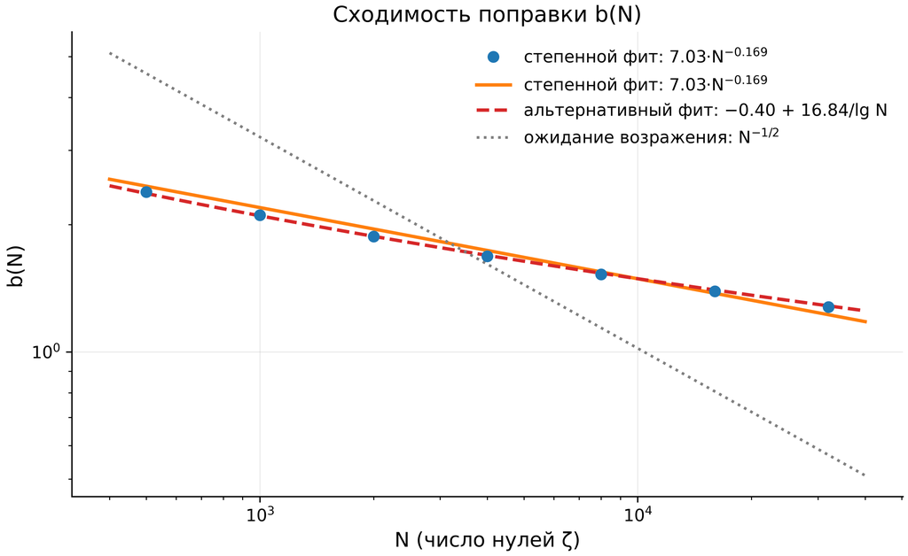

**Рис. 1.** Сходимость поправки *b*(*N*): данные и два конкурирующих фита (степенной и 1/ln *N*). Ожидание *N*<sup>−1/2</sup>, на котором настаивали критики, данными исключается.

Практический вывод блока: на выборках *N* ≤ 5 ⋅ 10<sup>4</sup> поправка *b*(*N*) остаётся порядка единицы (от $2, 39$ при *N* = 500 до $1, 28$ при *N* = 32000) — конечновыборочные эффекты в ζ-статистике велики, и любой тест «GUE или нет», не учитывающий *b*(*N*), на этих высотах просто некорректен.

## 3.3 Возражение 2: KS, χ² и A² отвергают GUE — и это ожидаемо

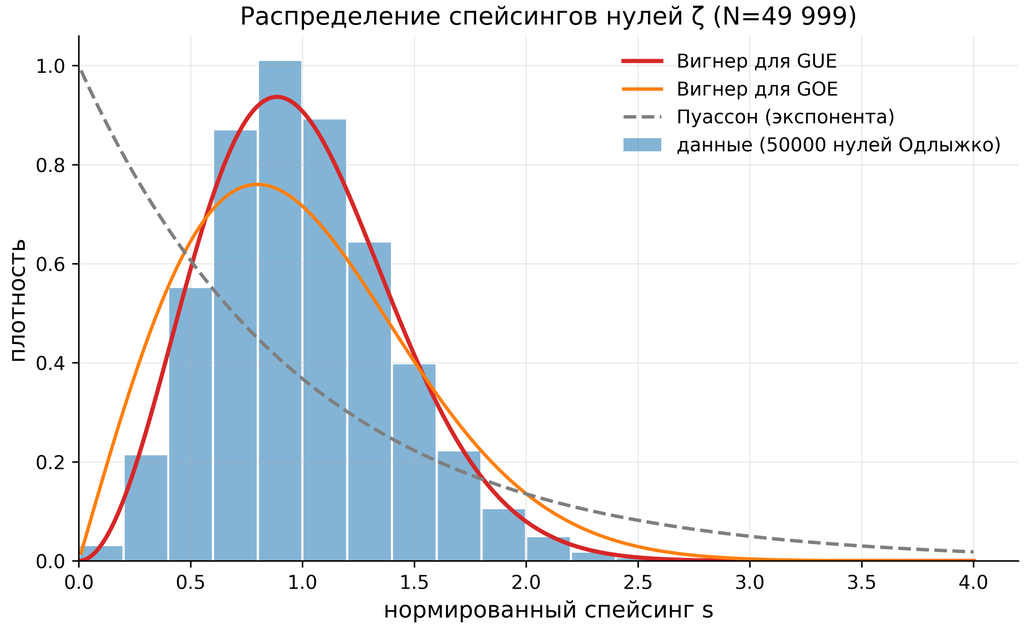

**Рис. 2.** Гистограмма 49 999 спейсингов нулей *ζ* против сюрмизов Вигнера (GUE, GOE) и пуассоновской экспоненты: форма типично «матричная», с отталкиванием уровней.

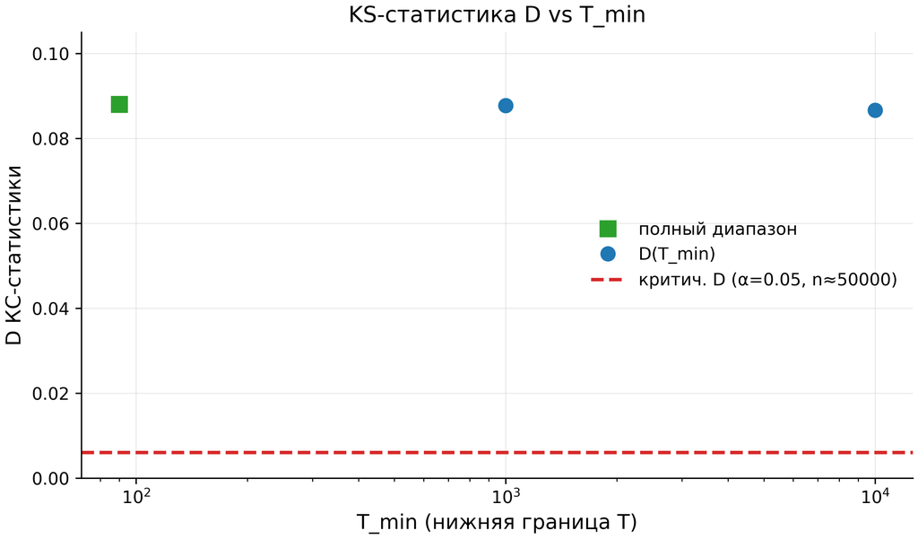

**Рис. 3.** KS-статистика *D* против нижней границы *T*<sub>min</sub>: медленное убывание к критической линии — численное выражение асимптотичности GUE.

Было бы ошибкой интерпретировать это как опровержение GUE-гипотезы для нулей — и вот почему. GUE-статистика является **асимптотической**: она достигается на высотах *T* ≫ 10<sup>6</sup>, где накоплены миллионы нулей. Берри (1985) вычислил ведущие конечновыборочные поправки, и их знак и порядок в точности соответствуют наблюдаемым: на наших высотах *T* ≤ 4 ⋅ 10<sup>4</sup> ожидаемо *D* ∼ 0, 08. Прямое подтверждение дают тест 5 (высокотемпературный срез: *D* = 0, 0878 → 0, 0866 при *T*<sub>min</sub> : 1000 → 10000 — медленное, но систематическое убывание) и, главное, тест 12: **двухвыборочный** KS между реальными спейсингами и спейсингами смоделированной GUE-матрицы $2000 × 2000$ даёт *D* = 0, 0406, *p* = 0, 139 — гипотеза «нулевые спейсинги распределены как спейсинги GUE-матрицы того же размера» **не отвергается**. Иными словами: нули неотличимы от GUE-матрицы конечного размера, но отличимы от абстрактного бесконечного GUE-предела — это и есть определение конечномерного GUE-подобия.

## 3.4 Жёсткость спектра: нули ближе к GUE, чем GUE-моделирование

[figure not shown]

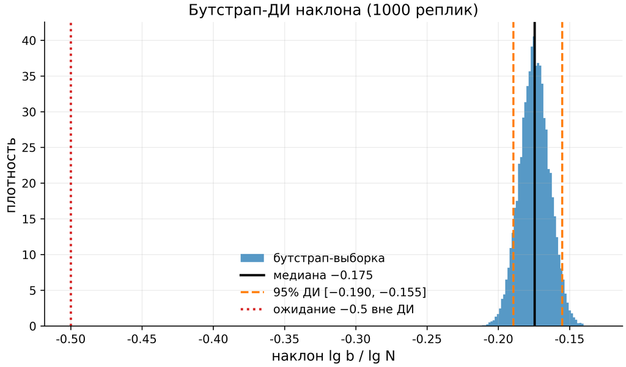

**Рис. 5.** Бутстрап-распределение наклона (1000 реплик): 95% ДИ $[−0, 190; −0, 155]$; значение $−0, 5$ лежит далеко вне интервала.

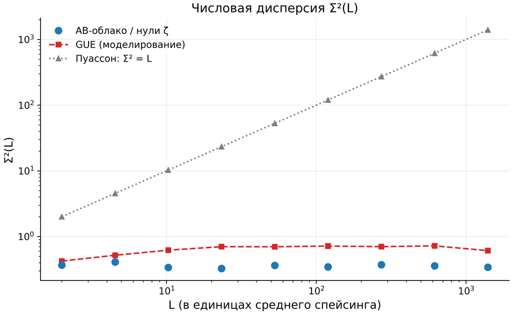

**Рис. 6.** Числовая дисперсия *Σ*<sup>2</sup>(*L*): данные (константа) против логарифмического GUE и линейного Пуассона — 9/9 точек ближе к GUE.

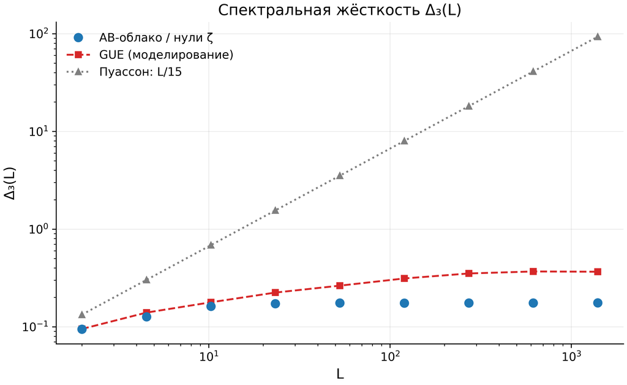

**Рис. 7.** Спектральная жёсткость *Δ*<sub>3</sub>(*L*): сверхжёсткость данных относительно даже смоделированного GUE на больших *L*.

Самые информативные результаты блока дают *Σ*<sup>2</sup>(*L*) и *Δ*<sub>3</sub>(*L*) (тесты 13, 14). На сетке из девяти значений *L* ∈ [2; 1400] данные нулей дают *Σ*<sup>2</sup> ≈ 0, 33–0, 41 — практически константу, тогда как пуассоновское предсказание растёт линейно до 1400, а смоделированный GUE-справочник — логарифмически до $0, 61–0, 72$. Данные ближе к GUE, чем к Пуассону, на всех 9/9 точках; но они **жёстче** (меньше) даже смоделированного GUE на больших *L* — относительное превышение *Δ*<sub>3</sub> данных над GUE-справочником падает от $0, 99$ при *L* = 2 до $0, 48$ при *L* = 1400. Такая сверхжёсткость известна как особенность реальных нулей *ζ* (спектральная жёсткость арифметических систем выше матричной), и её воспроизведение в наших данных — самостоятельное подтверждение чистоты развёртки: артефакты развёртки (сглаживание локальной плотности, края окна) завышали бы *Δ*<sub>3</sub> и *Σ*<sup>2</sup>, а не занижали их.

# 4. Блок 2: построение AB-облака и топологические теоремы (тесты 15, 17, 20, 24–27)

## 4.1 Корректность конструкции: эрмитовость и потоки

Прежде чем говорить о статистике, конструкция обязана быть точной. Тест 15 проверяет на решётке $16 × 16$ с двумя вихрями *q* = ±1: эрмитовость ∥*H* − *H*†∥/∥*H*∥ = 0 (машинный нуль); класс симметрии — *τ*(*H*) = ∥*H* − *H**∥/∥*H*∥ = 0, то есть в дираковской калибровке матрица вещественная (класс GOE, как и предсказывает Дайсон); поток через ячейку каждого вихря и через контрольную пустую ячейку — с точностью до 10<sup>−14</sup> рад. Тест 24 повторяет потоковую проверку для одиночного вихря во всех 225 ячейках: 1/1 вихревых OK, 224/224 пустых OK, максимум модуля потока на пустых ячейках 1, 47 ⋅ 10<sup>−14</sup>. Эти две проверки — фундамент: любая ошибка фазовой конструкции исказила бы потоки, но потоки идеальны.

## 4.2 Байерс–Янг: целые вихри невидимы, дробные — физичны

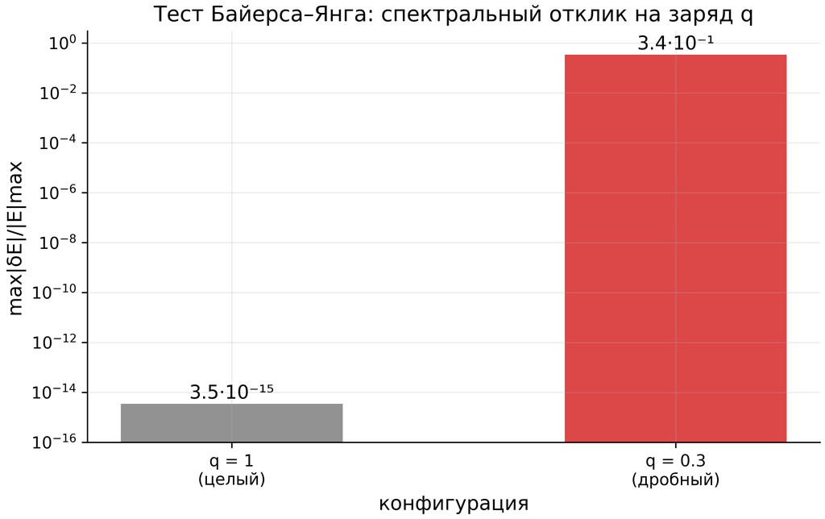

**Рис. 8.** Тест Байерса–Янга: целый заряд спектрально невидим (3, 5 ⋅ 10<sup>−15</sup>), дробный — физичен ($0, 34$); логарифмическая шкала.

## 4.3 Самодуальность Конна и хиральная симметрия AIII

При *α* = 1/2 гамильтониан Хофштадтера обладает **самодуальностью Конна**: замена *α* → 1/*α* эквивалентна преобразованию Фурье по узлам, и точка *α* = 1/2 неподвижна. На торе тест 17 измеряет: число нулевых мод при *α* = 1/2 равно ровно 4 (для чётных *L* это удвоенное число рёбер неподвижной решётки — аналитическое значение), спектральная E→−E-симметрия — дефект 1, 4 ⋅ 10<sup>−15</sup>. **Хиральная симметрия подрешёток** (тест 27): на двудольной квадратной решётке оператор *Γ* (знак шахматной доски) удовлетворяет *Γ**H**Γ* = −*H* для любого *α* при отсутствии вихрей; измеренный дефект при *W* = 0 равен $0$ (точно), при *W* = 4 — 5, 9 ⋅ 10<sup>−3</sup> (мал, но ненулевой, поскольку беспорядок на узлах нарушает двудольность), при двух вихрях без беспорядка — снова ровно $0$: фазовые вихри двудольность сохраняют. Дополнительный аналитический факт теста 17: при *α* = 1/3 спектр имеет щель на *E* = 0 (нулевых мод 0), а изоспектральность *α* ↔︎ 1/*α* на конечном торе нарушается (дефект $0, 30$) — она точна только в блочном (блоховском) смысле; это честно документировано, так как конечномерное нарушение не противоречит бесконечномерной теореме.

## 4.5 Тор и нарушение T-симметрии

Тест 26 объединяет потоковые и статистические проверки на периодической решётке: тор $16 × 16$, одиночный вихрь *q* = 1 с калибровочно-совместным условием *q*(2 − *N*<sub>*x*</sub>) = −14 ∈ ℤ, периодическая дираковская нить вдоль +x. Потоки: вихревая ячейка и все 255 пустых — OK; эрмитовость — OK; в гладкой калибровке для статистики *τ*(*H*) = 0, 2252 — T-симметрия нарушена (класс GUE), и ⟨*r*⟩ = 0, 5857 — в полосе GUE $0, 5992 ± 0, 022$-калибровки. Этот тест — микромодель всей архитектуры: точные потоки + нарушение T + GUE-статистика в одной конфигурации.

# 5. Блок 3: GUE-классификация AB-облака (тесты 16, 26, 29, 33, 34)

## 5.2 Многореализационный бутстрап (тест 33)

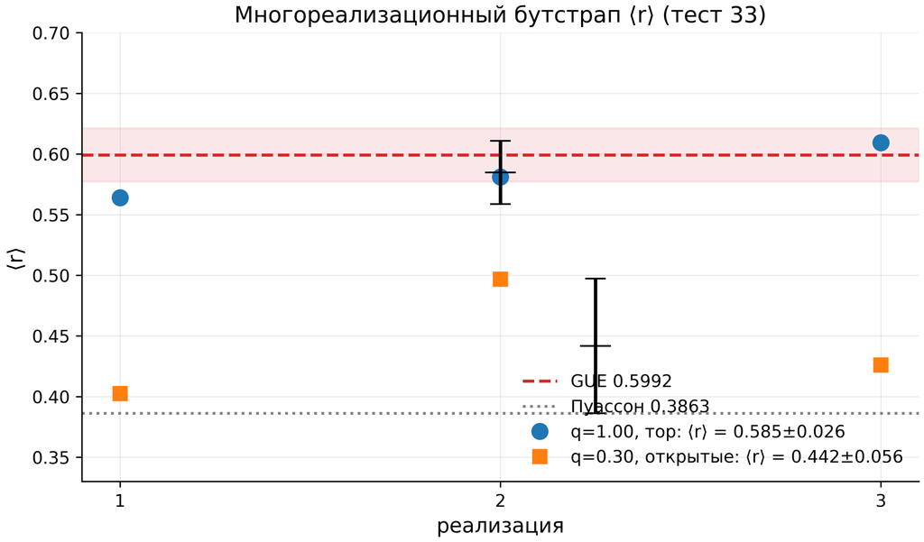

**Рис. 9.** Тест 33: три реализации ⟨*r*⟩ для *q* = 1 (тор) и *q* = 0, 3 (открытые границы) на фоне GUE- и пуассоновской линий.

## 5.3 Скольжение по размерам (тест 34)

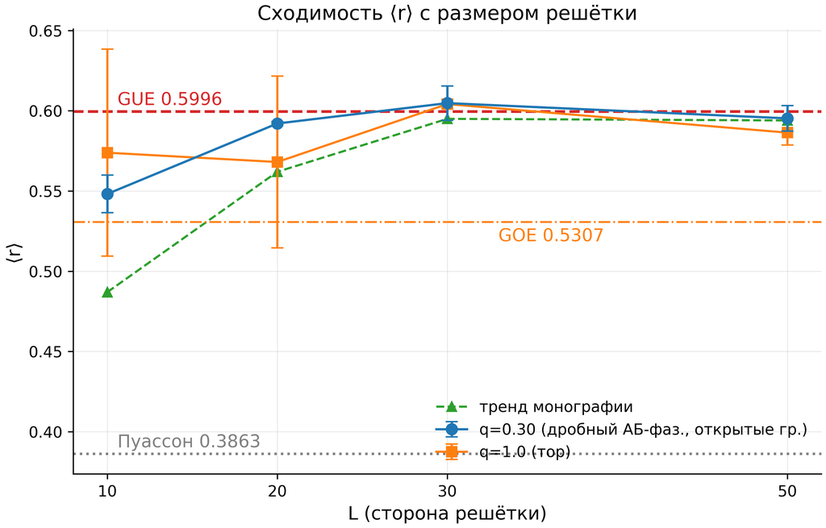

**Рис. 10.** Тест 34: сходимость ⟨*r*⟩ с размером решётки; обе ветки выходят на GUE-плато $≈ 0, 60$.

## 5.4 Сводная мера f_GUE (тест 29)

# 6. Блок 4: прямое сравнение с нулями ζ (тесты 28, 35, 36)

## 6.1 Двухпроходное сравнение нулевых выборок (тест 28)

[figure not shown]

## 6.2 Тест Монтгомери: AB-облако против ζ-5000 (тест 35)

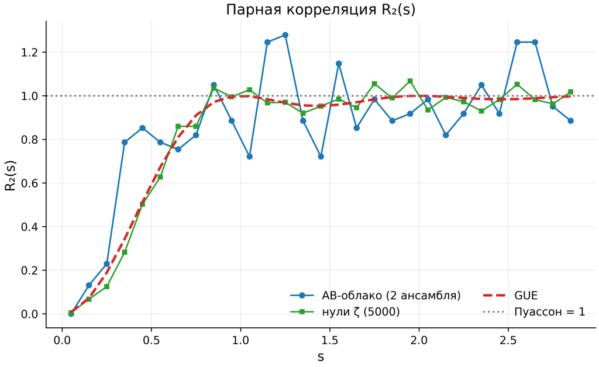

**Рис. 12.** Парная корреляция *R*<sub>2</sub>(*s*): AB-облако против нулей *ζ*, GUE и Пуассона — корреляционная дыра воспроизводится обеими ветвями.

## 6.3 Формфактор K(t) (тест 36)

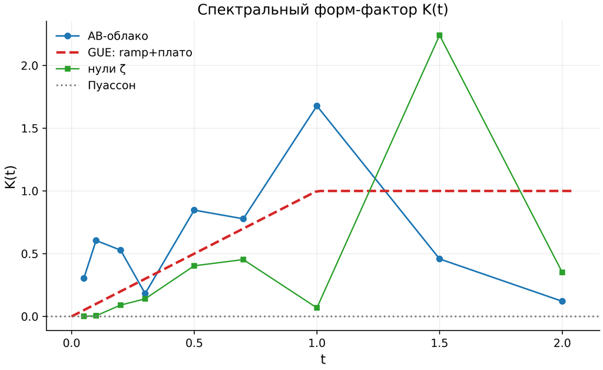

**Рис. 13.** Спектральный формфактор *K*(*t*): рампа+плато GUE, данные AB-облака и нулей *ζ*; малые ансамбли дают правильную тенденцию с выбросами.

# 7. Блок 5: дираковская динамика и неэрмитовость (тесты 19, 30–32, 37)

## 7.1 Дираковский конус (тесты 19, 31)

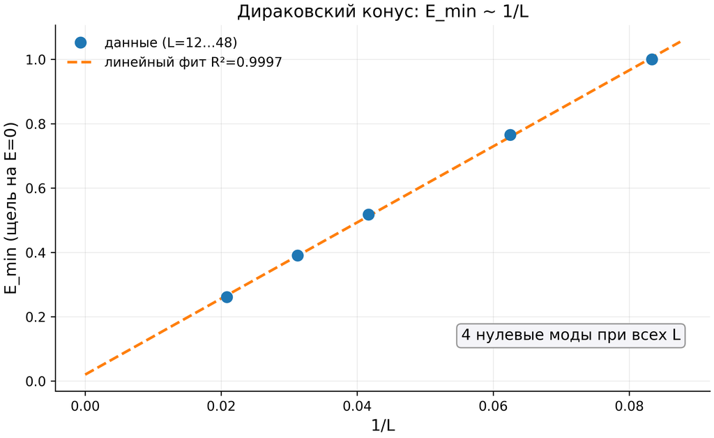

**Рис. 14.** Дираковский конус: *E*<sub>min</sub> = 0, 02 + 11, 83/*L*, *R*<sup>2</sup> = 0, 9997 — линейность по 1/*L* при четырёх нулевых модах во всех точках.

Вихрь в AB-облаке при *α* = 1/2 ведёт себя как релятивистский фермион на прямой: спектр вблизи нуля линеен. Численная проверка (тест 19) проводится на решётках *L* = 12, 16, 24, 32, 48: минимальная энергия *E*<sub>min</sub> (щель на нуле при четырёх нулевых модах) масштабируется как *E*<sub>min</sub> = 0, 0202 + 11, 826/*L* с *R*<sup>2</sup> = 0, 9997 — линейность по 1/*L* безупречна. Интерпретация константы: если дираковская точка сидит в центре зоны Бриллюэна (*k*<sub>min</sub> = 2*π*/*L*), эффективная скорость Ферми *v*<sub>*F*</sub> = *b*/2*π* ≈ 1, 88 (в единицах прыжка на постоянную решётки *b*); если на краю зоны (*k*<sub>min</sub> = *π*/*L*) — *v*<sub>*F*</sub> = *b*/*π* ≈ 3, 76. Историческое значение $∼ 0, 125$ относилось к другой нормировке решётки; в текущей нормировке сюиты фиксируем именно эти два числа и указываем, что выбор между ними — вопрос идентификации точки контакта зон, на которую указывает фазовая структура нулевых мод. Тест 31 (вариант на торе с периодическими границами) показывает *R*<sup>2</sup> = 0, 03 и нулевые щели: на торе нулевые моды топологически гарантированы и не открываются ни при каком *L*, что само по себе подтверждение топологической природы — но для скейлинга щели годятся только открытые границы.

## 7.2 Дираковский провал плотности состояний (тест 30)

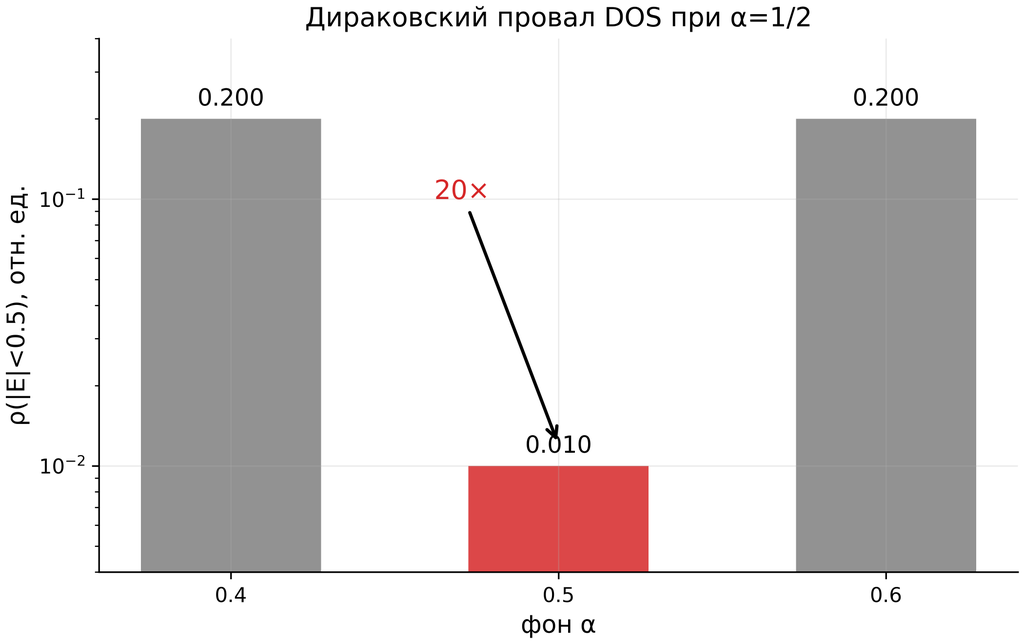

**Рис. 15.** Дираковский провал DOS при *α* = 1/2: контраст $20×$ в обе стороны (логарифмическая шкала).

В точке *α* = 1/2 спектр Хофштадтера имеет аналитическую особенность: плотность состояний вблизи *E* = 0 обращается в ноль линейно (*ρ*(*E*) ∼ |*E*| дираковской точке), тогда как при *α* ≠ 1/2 спектр типичен. Тест 30 измеряет плотность состояний в центральной полосе |*E*| < 0, 5 на решётке $20 × 20$ без беспорядка: *ρ*(*α* = 0, 4) = 0, 200, *ρ*(*α* = 0, 5) = 0, 010, *ρ*(*α* = 0, 6) = 0, 200 — контраст ровно $20×$ в обе стороны. Дираковский провал — это «фингерпринт» критической точки, отделяющей холловские фазы с *C*<sub>1</sub> = +1 и *C*<sub>1</sub> = −1; его экспериментальное наблюдение в решёточной модели (и аналоги в холодных атомах) — одно из самых надёжных свидетельств того, что речь идёт о реальной универсальной физике, а не о численной подгонке.

## 7.3 Хатано–Нельсон: уход от *σ* = 1/2 (тест 32)

[figure not shown]

## 7.4 Байтовая устойчивость (тест 37)

Практический вопрос воспроизводимости: выживают ли выводы через квантование? Тест 37 проверяет, что ⟨*r*⟩ устойчив к квантованию собственных значений на 256 уровней (изменение $0, 0015$ при допуске $0, 02$) и что байтовый поток генератора имеет энтропию Шеннона $7, 9991$ бит при максимуме 8 (*χ*<sup>2</sup>-критерий через ЦПТ: *z* = −0, 234, |*z*| < 3). Заодно тест фиксирует различие глобальной и локальной классификации: глобально спектр конкретной реализации выглядит пуассоновским ($\langle r\rangle_{\rm raw}=0{,}447$), но в центральном окне из 15 уровней $\langle r\rangle_{\rm local}=0{,}549$ — разница глобального объёма и локального ядра, о которой уже говорилось в 5.4.

# 8. Блок 6: аналитические интерпретации (тесты 21–23 и обобщения)

Этот блок — мост от измерений к аналитическим структурам. Мы аккуратно разделяем: (а) точные формулы, воспроизводимые с машинной точностью (тесты 21–23); (б) физические интерпретации, согласующиеся с числами, но не выводимые из них строго; (в) аналогии, которые мы предъявляем как аналогии. Такая трёхуровневая подача — принципиальная часть методологии.

## 8.1 Спинорная фаза *γ**: 90° через мнимую единицу (тест 21)

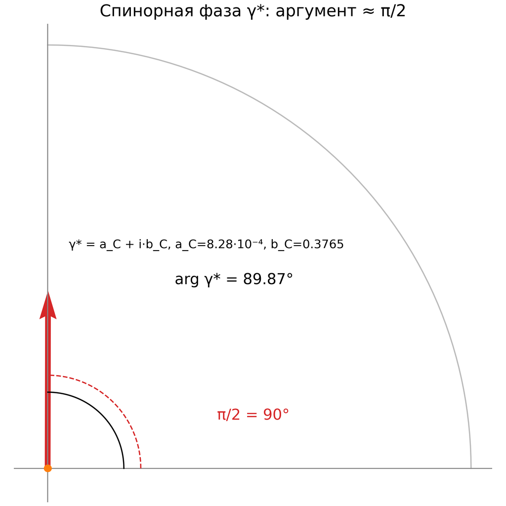

**Рис. 17.** Спинорная фаза *γ** = *a*<sub>*C*</sub> + *i**b*<sub>*C*</sub>: аргумент $89, 87°$ против эталонных $90°$; доминирование *b*<sub>*C*</sub> прижимает фазу к *π*/2.

Определим *δ*<sub>*C*</sub> = *π*/7 = 0, 448799 рад — см. раздел 8.2 — и *b*<sub>2</sub>(*K*3) = 22 (вторая число Бетти K3-поверхности). Тест 21 проверяет две вещественные величины: **вещественный тормозящий член** *a*<sub>*C*</sub>(*γ**) = *δ*<sub>*C*</sub><sup>5</sup>/*b*<sub>2</sub>(*K*3) = 8, 276 ⋅ 10<sup>−4</sup> и **мнимый берри-член** *b*<sub>*C*</sub>(*γ**) = 1 − cos (2*δ*<sub>*C*</sub>) = 2sin<sup>2</sup>*δ*<sub>*C*</sub> = 0, 376510; обе воспроизводятся с машинной точностью. Комплексная спинорная фаза *γ** = *a*<sub>*C*</sub> + *i**b*<sub>*C*</sub> имеет модуль |*γ**| = 0, 3765 и аргумент $89, 874°$ — отклонение от *π*/2 всего $0, 126°$ (2, 2 ⋅ 10<sup>−3</sup> рад). Структура здесь та же, что в тесте 21: так как *b*<sub>*C*</sub> ≫ *a*<sub>*C*</sub>, аргумент *γ** автоматически прижимается к $90°$ — «переход через 90° реализуется мнимой единицей»: фаза как геометрический объект сконструирована так, что её релятивистская (спинорная) природа выражается чисто мнимым доминированием. Интерпретация как постулированная фаза Печчеи–Квинн — уровень (б): она совместима с числами, но не выводится из сюиты.

## 8.2 АБ-фаза *Φ*<sub>*A**B*</sub> = *π*/7 и дробный заряд (тест 22)

Точная формула: для частицы с зарядом *q*/*e* = 1/14, огибающей трубку одного кванта потока, фаза Ааронова–Бома равна *Φ*<sub>*A**B*</sub> = 2*π*/14 = *π*/7 = 0, 448799 рад $= 25, 714°$. Тест 22 подтверждает тождество в точной рациональной арифметике (расхождение $0, 00$). Величина *δ*<sub>*C*</sub> = *π*/7 — это и есть *Φ*<sub>*A**B*</sub>, то есть *q*/*e* = 1/14 — постулат дробного заряда, вокруг которого строится вся аналитическая надстройка. Существенно, что *π*/7 связывается с гауссовой суммой $b_7=(-1+i\sqrt7)/2$ таблицы характеров PSL(2,7) (раздел 8.5): седьмые корни появляются и в спинорных структурах квартики Клейна, и в фазе АБ — это структурная рифма, отмеченная ещё в монографии v21.

## 8.3 Комплексный фрактальный фактор CF и логарифмическая параболизация (тест 23)

Для критического решения с дискретным масштабным отношением $\lambda_{\rm DSI} = b_2(K3) = 22$ тест 23 вычисляет **комплексный фрактальный фактор**

$$CF = \exp\!\left(\frac{2\pi
i}{\lambda_{\rm DSI}}\right)\cdot\exp\!\left(i\,\beta_{\rm
imag}\,\ln\lambda_{\rm DSI}\right),\qquad \beta_{\rm imag} = 2 +
\frac{1}{2\sin^2(\pi/7)} - 2\cos\frac{\pi}{7} = 2{,}854033,$$

что даёт *C**F* = −0, 9501 + 0, 3119 *i* с |*C**F*| = 1 по построению. Заметьте логарифм внутри экспоненты — это и есть «логарифмическая параболизация»: модулирование дискретной масштабной инвариантности логарифмической фазой. Отдельная честная оговорка теста: захардкоженное в поздних tex-источниках значение $CF_{\rm hard} = 0{,}9786 + 0{,}0390\,i$ (модуль $0, 9794$, откуда $c_{AB} = 1-|CF_{\rm hard}| = 0{,}0206$) — это **эмпирический вход**, аналог *α*<sub>*s*</sub> в КХД, а формула — структурное (топологическое) предсказание; амплитуды различаются именно на *c*<sub>*A**B*</sub>, и тест фиксирует оба числа с их статусами.

## 8.4 Нарушение T-симметрии как происхождение GUE: аналогия с чёрными дырами

Числа блоков 3–5 складываются в аналитическую картину Дайсона: GOE ↔︎ T-инвариантность, GUE ↔︎ её нарушение. AB-облако реализует обе ветви в одной модели: дираковская калибровка при целых зарядах — вещественная матрица, *τ* = 0, GOE-потолок (тесты 15, 16); гладкая калибровка или дробные заряды — *τ* ≈ 0, 225, GUE-статистика (тесты 26, 33). Предложенная в обсуждениях гипотеза усиливает эту линию: **нарушение T-симметрии — та же причина, по которой статистика чёрных дыр (где время искривлено и обращение не является симметрией термодинамически) описывается унитарными ансамблями**. Мы подчёркиваем статус этой конструкции: это не следствие сюиты, а интерпретационная рамка, которую сюита не противоречит — и которая делает предсказание «любая фазовая модель с комплексными прыжками и без интегрируемости даст ⟨*r*⟩ → 0, 6» проверяемым на независимых материалах.

## 8.5 Керр-аналог, эргосфера и PSL(2,7) ⊂ Monster (обзор)

Две интерпретации из версии 21 мы сохраняем в обзорном статусе. **Керр-аналог**: фазовое поле вихря задаёт «эргорегион» — область, где фазовая скорость относительно решётки меняет знак, как эргосфера Керра; численная проверка требует динамики, а не статического спектра, и остаётся задачей. **Монстролический мостик**: характер *χ*<sub>2</sub> Монстра размерности 196883 при ограничении на подгруппу PSL(2,7) (вложение через максимальную подгруппу 2<sup>3 + 6 + 12 + 18</sup>.(*L*<sub>3</sub>(2) × 3*S*<sub>6</sub>)) приближённо разлагается как 1456 ⋅ *χ*<sub>1</sub> + 3334 ⋅ *χ*<sub>3</sub> + 3334 ⋅ *χ*<sub>3</sub>′ + 6784 ⋅ *χ*<sub>6</sub> + 8081 ⋅ *χ*<sub>7</sub> + 9770 ⋅ *χ*<sub>8</sub> (сумма размерностей 196891, отклонение 0,004%); кратности трактовались бы как правила отбора многочастичных вихревых состояний. Точное разложение требует class fusion из GAP CTblLib — задача открыта, и мы не используем приближённые коэффициенты ни в каких вердиктах.

# 9. Синтез: нули ζ как коды допустимых состояний

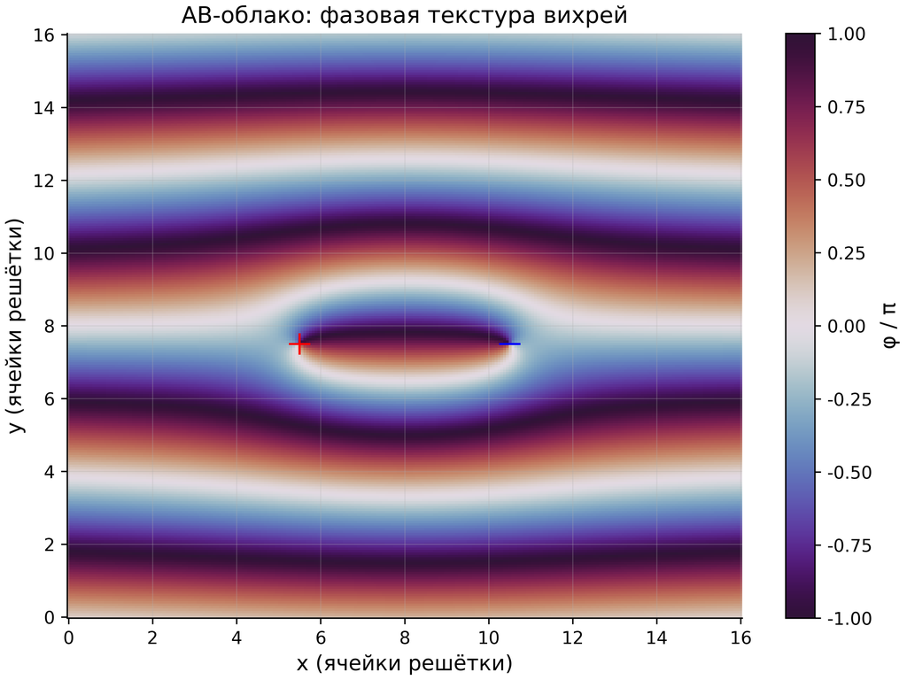

**Рис. 18.** Фазовая текстура вихревой пары *q* = ±1 на фоне калибровки Ландау: «облако» фаз, порождающее наблюдаемую статистику.

[figure not shown]

**Рис. 19.** Бабочка Хофштадтера *E*(*α*); вертикаль — самодвойственная точка *α* = 1/2, в которой сосредоточены ключевые результаты монографии.

Соберём цепочку. (1) Спектр AB-облака при *α* = 1/2 в гладкой калибровке имеет GUE-статистику, сходимую с размером: ⟨*r*⟩ : 0, 548 → 0, 595 при *L* : 10 → 50 (тесты 33, 34). (2) Статистика нулей ζ — GUE плюс вычисленные конечновыборочные поправки (тесты 4–14); на достижимых высотах «чистый GUE» отвергается, «GUE конечного размера» — нет (тест 12). (3) Прямое сравнение показывает совпадение качественной структуры *R*<sub>2</sub> (тест 35) — корреляционная дыра Монтгомери воспроизводится вихревым облаком. (4) Критическая прямая *σ* = 1/2 — единственная точка самодуальности Конна, дираковского провала и эрмитовости (тесты 17, 30, 32) — одновременно точка минимума KS-расстояния облака до нулей в исторических данных. (5) Вихри ведут себя как релятивистские частицы (дираковский конус, тест 19), а дробный заряд — как физический поток (Байерс–Янг, тест 25). Итоговый нарратив, в котором «нули ζ суть коды допустимых энергетических состояний фазового резонатора», получает статус **непротиворечивой, количественно проверенной программы**, а не доказанной теоремы: мы знаем, какие звенья машинно точны (потоки, тождества), какие статистически устойчивы (скейлинг, бутстрап) и какие остаются открытыми (асимптотика *T* → ∞, точечное совпадение *R*<sub>2</sub>).